# Project Final Submission Template

### Step 1a: Planning

#### Identify the information in the file your program will read

Describe (all) the information that is available. Be sure to note any surprising or unusual features. (For example, some information sources have missing data, which may be blank or flagged using values like -99, NaN, or something else.)

The information I have include a total of 176 countries with their 2021 data on :

- country name
- bottom 50% pre-tax income share
- top 10% pre-tax income share
- top 1% pre-tax income share
- bottom 50% wealth share
- top 10% wealth share
- top 1% wealth share
- the country's continent

However, there are some missing information on the wealth distribution of 4 places: Belarus, Hong Kong, Kosovo, and Zanzibar

### Step 1b: Planning

#### Brainstorm ideas for what your program will produce

#### Select the idea you will build on for subsequent steps

You must brainstorm at least three ideas for graphs or charts that your program could produce and choose the one that you'd like to work on. You can choose between a line chart, histogram, bar chart, scatterplot, or pie chart.

If you would like to change your project idea from what was described in the proposal, you will need to get permission from your project TA. This is intended to help ensure that your new project idea will meet the requirements of the project. Please see the project proposal for things to be aware of when communicating with your project TA.

Brain Storm ideas:

1. Given a continent and an income level(top 1%, top 10% or bottom 50%) and produce a histogram of the difference in percentage from income share to wealth share.(((wealth share - pre-tax income)/ pre-tax income))*100%
2. Produce a scatter plot of which: x axis is the income share per percentage of population (devide the pre-tax income share of top 1% by 1, top 10% by 10, and bottom 50% by 50) and y axis is growth from income to wealth (((net wealth share / pre-tax income)-1)*100%).
3. Produce a clustered bar chart, where there will be 6 items representing six continents except for Antarctica(there's no data on countries in Antarctica). And each section will contain three bars of the average income share of top 1%, top 10%, and bottom 50%.

The one I'd like to work on:

2. Produce a scatter plot of which: x axis is the income share per percentage of population (devide the pre-tax income share of top 1% by 1, top 10% by 10, and bottom 50% by 50) and y axis is the growth from income to wealth (((net wealth share / pre-tax income)-1)*100%).

### Step 1c: Planning

#### Write or draw examples of what your program will produce

You must include an image that shows what your chart or plot will look like. You can insert an image using the Insert Image command near the bottom of the Edit menu.

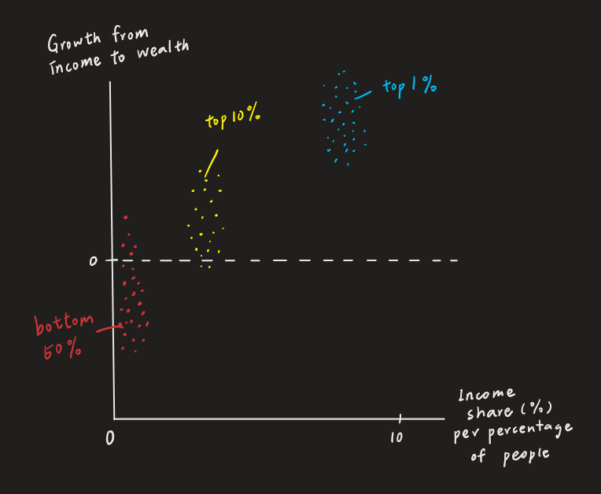

### Step 2a: Building

#### Document which information you will represent in your data definitions

Before you design data definitions in the code cell below, you must explicitly document here which information in the file you chose to represent and why that information is crucial to the chart or graph that you'll produce when you complete step 2c.

The information I choose to represent are :

- country name -> to make the data more readable
- bottom 50% pre-tax income share-> for calculation for y axis and numerical value for x axis. Present as float.
- top 10% pre-tax income share -> for calculation for y axis and numerical value for x axis. Present as float.
- top 1% pre-tax income share -> for calculation for y axis and numerical value for x axis. Present as float.
- bottom 50% wealth share -> for calculation for y axis. Present as float.
- top 10% wealth share -> for calculation for y axis. Present as float.
- top 1% wealth share -> for calculation for y axis. Present as float.

#### Design data definitions

```python
from cs103 import *
from typing import NamedTuple, List
import csv
import matplotlib.pyplot as plt

##################
# Data Definitions

WidIndex = NamedTuple('WidIndex', [('country',str),           # to make the data more readable
                                  ('bottom_50_income',float), # in range[0,1]
                                  ('top_10_income',float),    # in range[0,1]
                                  ('top_1_income',float),     # in range[0,1]
                                  ('bottom_50_wealth',float), # in range(...,1] because some people in bottom 50% have debt.
                                  ('top_10_wealth',float),    # in range[0,1]
                                  ('top_1_wealth',float)])    # in range[0,1]

# interp. The Wid(world inequality database) index, which contains the country name,
# bottom 50% pre-tax income share, top 10% pre-tax income share, top 1% pre-tax income share,
# bottom 50% wealth share, top 10% wealth share and top 1% wealth share

WI1 =  WidIndex('Cameroon',0.11,0.52,0.16,0.03,0.68,0.35)
WI2 =  WidIndex('Nigeria',0.16,0.43,0.12,0.05,0.59,0.26)
WI3 =  WidIndex('North Korea',0.18,0.38,0.12,0.05,0.58,0.25)
WI4 =  WidIndex('Chile',0.09,0.63,0.27,-0.01,0.80,0.49) # bottom 50% wealth is negative because people have debt.


@typecheck
def fn_for_wid_index(wi:WidIndex)->...:
    # template based on compound(7 fields)
    return ...(wi.country,
              wi.bottom_50_income,
              wi.top_10_income,
              wi.top_1_income,
              wi.bottom_50_wealth,
              wi.top_10_wealth,
              wi.top_1_wealth)

# List[WidIndex]
# interp. a list of WidIndex

LOWI0 = []
LOWI1 = [WI1, WI2]
LOWI2 = [WI1, WI2, WI3]

@typecheck
def fn_for_lowi(lowi: List[WidIndex]) -> ...:
    # template based on arbitrary sized and reference rule
    # description of the accumulator
    acc = ... # type:...
    for wi in lowi:
        acc = ...(fn_for_wid_index(wi),acc)
    return ...(acc)
```

### Step 2b and 2c: Building

#### Design a function to read the information and store it as data in your program

#### Design functions to analyze the data

Complete these steps in the code cell below. You will likely want to rename the analyze function so that the function name describes what your analysis function does.

Unless approved by your project TA, you **cannot** use libraries such as `numpy` or `pandas`. The project is meant as a way for you to demonstrate your knowledge of the learning goals in this course. While it is convinent to use external libraries, it will do all the work and will not help us gauge your mastery of the concepts.

You also cannot use built in list functions (e.g., `sum` or `average`) when writing code to do your substantial computation. Normally we encourage you to make use of what is already available but in this case, the final project involves demonstrating skills from class (e.g., how to work with a list). Using pre-built functions for this does not enable you to demonstrate what you know.

If you wish to change your project idea, you must **first** obtain permission from your TA. When contacting your TA, please provide a valid reason for why you want to change your project. Each time you change your topic idea, your TA will have to evaluate it to see if it will meet all of the project requirements. This is non-trivial task during one of the busiest times of the semester. As such, the deadline for project idea changes will be 3 business days before the deadline. Note that the deliverable deadline will not be extended and there is no compensation for the time you spent on the previous idea.

```python
###########
# Functions
@typecheck
def read(filename: str) -> List[WidIndex]:
    """
    reads information from the specified file and returns a list of WidIndex
    from data that's reliable(not empty).
    """
    # return []  #stub
    # Template from HtDAP
    # lowi contains the result so far
    lowi = [] # type: List[WidIndex]

    with open(filename) as csvfile:

        reader = csv.reader(csvfile)
        next(reader) # skip header line

        for row in reader:
            # row[0] -> country name - str
            # row[2] -> bottom 50% income - str
            # row[3] -> top 10% income - str
            # row[4] -> top 1% income - str
            # row[5] -> bottom 50% wealth - str
            # row[6] -> top 10% wealth - str
            # row[6] -> top 1% wealth - str
            if is_reliable(row):
                wi = WidIndex(row[0], parse_float(row[2]), parse_float(row[3]),
                               parse_float(row[4]), parse_float(row[5]),
                               parse_float(row[6]), parse_float(row[7]))
                lowi.append(wi)

    return lowi

@typecheck
def is_reliable(row:List[str])->bool:
    '''
    Return True if the top 1% wealth(row[7]), top 10% wealth(row[6])
    and bottom 50% wealth(row[5]) is not an empty string,
    return False if not.
    ASSUMES: row is a full row of data from a WidIndex data information file.
    Data except for row[5], row[6] and row[7] are all reliable(not empty).
    '''
    # return True # stub
    if row[5] == '' or row[6] == '' or row[7] == '':
        return False
    else:
        return True

########################
# tests
########################

# test for is_reliable
start_testing()
expect(is_reliable(['Algeria','Africa','0.19','0.38','0.1','0.05','0.58','0.25']), True) # is reliable
expect(is_reliable(['Zanzibar','Africa','0.13','0.51','0.18','','','']), False) # not reliable(missing row[5],[6],[7])
expect(is_reliable(['Algeria','Africa','0.19','0.38','0.1','','0.58','0.25']), False) # is not reliable (missing row[5])
expect(is_reliable(['Algeria','Africa','0.19','0.38','0.1','0.05','','0.25']), False) # is not reliable (missing row[6])
expect(is_reliable(['Algeria','Africa','0.19','0.38','0.1','0.05','0.58','']), False) # is not reliable (missing row[7])

summary()


# tests for read
start_testing()
expect(read('test_empty.csv'), []) # empty data
expect(read('test_small1.csv'), [WidIndex('Algeria',0.19,0.38,0.1,0.05,0.58,0.25)]) # all data is reliable
expect(read('test_small2.csv'), [WidIndex('Algeria',0.19,0.38,0.1,0.05,0.58,0.25),
                                WidIndex('Benin',0.11,0.55,0.18,0.01,0.74,0.41)]) # one of the data is not reliable
summary()
```

```
5 of 5 tests passed
3 of 3 tests passed
```

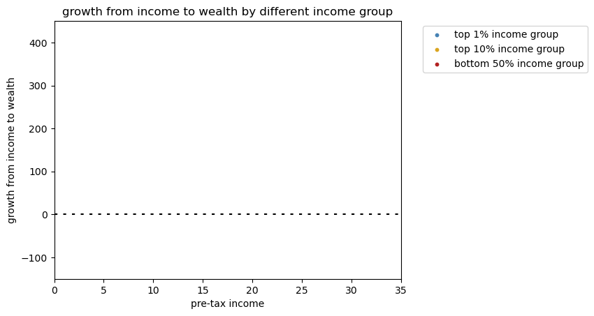

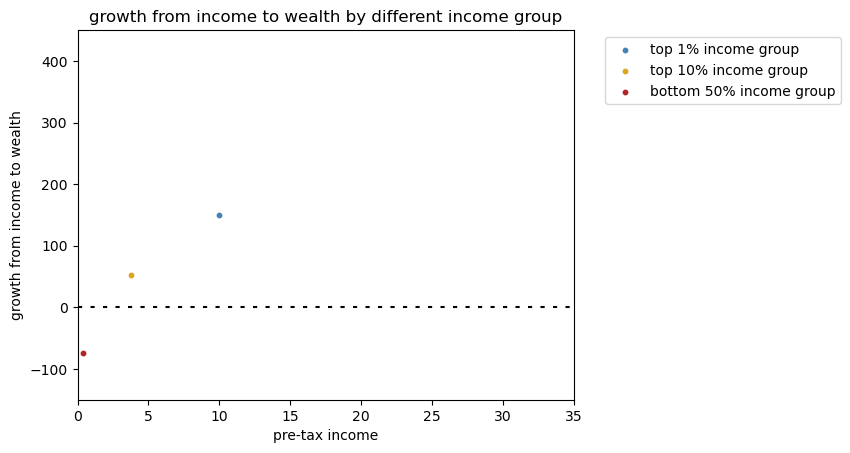

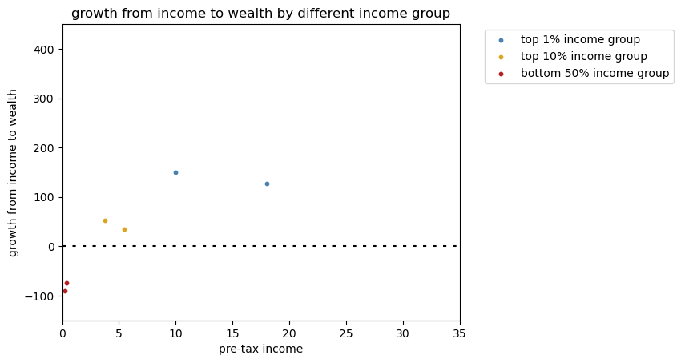

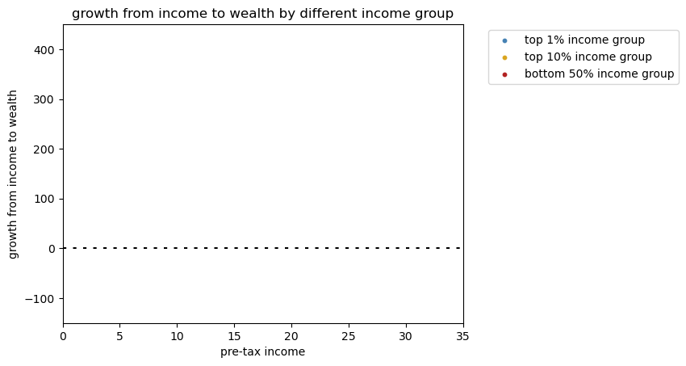

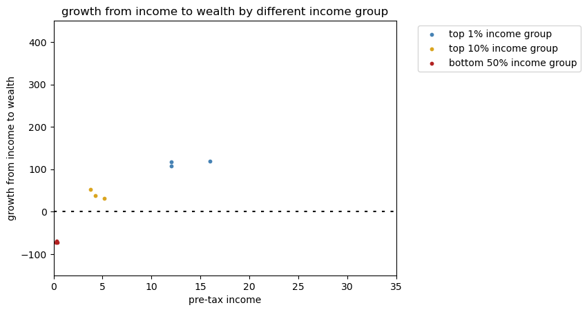

```
8 of 8 tests passed
3 of 3 tests passed
3 of 3 tests passed
6 of 6 tests passed
3 of 3 tests passed
3 of 3 tests passed
3 of 3 tests passed
```

```python
@typecheck
def main(filename:str) -> None:
    '''
    gets a filename(csv file) and show a scatterplot of
    income share per percentage of people v.s. growth from income to wealth
    with three groups of people:
    bottom 50% income, top 10% income and top 1% income group
    '''
    # return None # stub
    # template based on composition
    show_scatterplot(read(filename))
    return None

@typecheck
def show_scatterplot(lowi:List[WidIndex]) -> None:
    """
    gets a list of WidData and display a scatterplot of
    income share per percentage of people v.s. growth from income to wealth

    Assumes that the lengths of ages, salaries, and counts are all equal
    """
    # return None #stub
    # Template based on visualization

    x_50 = income_per_percentage_bottom_50(lowi)
    y_50 = growth_of_group(lowi, 50)

    x_10 = income_per_percentage_top_10(lowi)
    y_10 = growth_of_group(lowi, 10)

    x_1 = income_per_percentage_top_1(lowi)
    y_1 = growth_of_group(lowi, 1)

    # areas = convert_counts_to_areas(counts)

    # set the labels for the axes
    plt.xlabel('pre-tax income')
    plt.ylabel('growth from income to wealth')
    plt.title('growth from income to wealth by different income group')

    # range for the axes
    # [x-min, x-max, y-min, y-max]
    plt.axis([0,35,-150,450])

    # create the scatterplot, with markers that are red (c='r') and triangular (marker='^')
    plt.plot([0, 100],[0, 0],'black',dashes=[2, 4])
    plt.scatter(x_1,y_1,marker='o', c='steelblue', label='top 1% income group',s=10)
    plt.scatter(x_10,y_10,marker='o', c='goldenrod', label='top 10% income group',s=10)
    plt.scatter(x_50,y_50,marker='o', c='firebrick', label='bottom 50% income group', s=10)
    plt.legend(bbox_to_anchor=(1.05, 1), loc=2)

    # show the plot
    plt.show()

    return None

@typecheck
def growth(income:float, wealth:float) -> float:
    '''
    gets a income and wealth and return the growth percentage from income and wealth to 1 decimal,
    For example:
    if income is 10 and wealth is 15, then the growth percentage will be 50% -> 50
    if income is 9 and wealth is 4, then the growth rate will be -55.55555% ->-55.6
    ASSUME: income is not 0
    '''
    # template based on atomic non-distinct
    return round((wealth-income)/income * 100,1)

@typecheck
def get_income_share(wi: WidIndex, percentage:int)->float:
    '''
    gets a wid index and a specific income percentage group,
    where the percentage can be 1(top 1%), 10(top 10%) or 50(bottom 50%) in int.
    returns the income share of the group of the given percentage.
    '''
    # template based on Wid Index
    # return 0 # stub

    if percentage == 1:
        return wi.top_1_income
    elif percentage == 10:
        return wi.top_10_income
    elif percentage == 50:
        return wi.bottom_50_income

@typecheck
def get_wealth_share(wi: WidIndex, percentage:int)->float:
    '''
    gets a wid index and a specific wealth percentage group,
    where the percentage can be 1(top 1%), 10(top 10%) or 50(bottom 50%) in int.
    returns the wealth share of the group of the given percentage.
    '''
    # template based on Wid Index
    # return 0 # stub

    if percentage == 1:
        return wi.top_1_wealth
    elif percentage == 10:
        return wi.top_10_wealth
    elif percentage == 50:
        return wi.bottom_50_wealth

@typecheck
def growth_of_group(lowi:List[WidIndex], percentage: int)->List[float]:
    '''
    gets a list of WidIndex and returns a list of float of the growth percentage from income and wealth
    of bottom given income percentage group.
    the percentage can be 1, 10 or 50(int)
    1 represents the top 1% income group
    10 represents the top 10% income group
    50 represents the bottom 50% income group
    '''
    # template from List[WidIndex]
    # return [] # stub

    # the current list of float of the growth percentage from income and wealth of the given group.
    current_list = [] # type: List[float]
    for wi in lowi:
        current_list.append(growth(get_income_share(wi, percentage), get_wealth_share(wi, percentage)))
    return current_list

@typecheck
def income_per_percentage_bottom_50(lowi:List[WidIndex])->List[float]:
    '''
    gets a list of WidIndex and returns a list of float of the income per percentage of the
    bottom 50% income group. which is the (income share for bottom 50%)/50*100
    '''
    # template from List[WidIndex]
    # return [] # stub

    # the current list of float of income per percentage of the bottom 50% income group.
    current_list = [] # type: List[float]
    for wi in lowi:
        income_per_percentage_50 = get_income_share(wi, 50)/50*100
        current_list.append(income_per_percentage_50)
    return current_list

@typecheck
def income_per_percentage_top_10(lowi:List[WidIndex])->List[float]:
    '''
    gets a list of WidIndex and returns a list of float of the income per percentage of the
    top 10% income group. which is the (income share for bottom 10%)/10*100(%)
    '''
    # template from List[WidIndex]
    # return [] # stub

    # the current list of float of income per percentage of the bottom 50% income group.
    current_list = [] # type: List[float]
    for wi in lowi:
        income_per_percentage_10 = get_income_share(wi, 10)/10*100
        current_list.append(income_per_percentage_10)
    return current_list


@typecheck
def income_per_percentage_top_1(lowi:List[WidIndex])->List[float]:
    '''
    gets a list of WidIndex and returns a list of float of the income per percentage of the
    top 10% income group. which is the (income share for bottom 1%)/1*100(%)
    '''
    # template from List[WidIndex]
    # return [] # stub

    # the current list of float of income per percentage of the bottom 50% income group.
    current_list = [] # type: List[float]
    for wi in lowi:
        income_per_percentage_1 = get_income_share(wi, 1)/1*100
        current_list.append(income_per_percentage_1)
    return current_list


########################
# tests
########################
# tests for main
expect(main('test_empty.csv'), None)
expect(main('test_small1.csv'), None)
expect(main('test_small2.csv'), None)

# expects to look like
# test_empty.csv
#
#      growth from income to wealth by different income group
#
# growth from income
#   to wealth
#       |
#    400|                                 . top 1% income group
#       |                                 . top 10% income group
#    300|                                 . bottom 50% income group
#       |
#    200|
#       |
#    100|
#       |
#      0|--------------------------------
#       |
#   -100|
#       |________________________________
#        0      10      20      30
#                   pre-tax income

# test_small1.csv
#
#      growth from income to wealth by different income group
#
# growth from income
#   to wealth
#       |
#    400|                                 . top 1% income group
#       |                                 . top 10% income group
#    300|                                 . bottom 50% income group
#       |
#    200|
#       |
#    100|        .
#       |   .
#      0|--------------------------------
#       |.
#   -100|
#       |________________________________
#        0      10      20      30
#                   pre-tax income

# test_small2.csv
#
#      growth from income to wealth by different income group
#
# growth from income
#   to wealth
#       |
#    400|                                 . top 1% income group
#       |                                 . top 10% income group
#    300|                                 . bottom 50% income group
#       |
#    200|
#       |        .
#    100|               .
#       |   ..
#      0|--------------------------------
#       |.
#   -100|.
#       |________________________________
#        0      10      20      30
#                   pre-tax income

# colors can't be show by the graph but:
# bottom 50%(the left) will be shown in blue, top 10%(the middle) in yellow, and top 1%(the right) in blue




# tests for show_scatterplot
expect(show_scatterplot(LOWI0), None)
expect(show_scatterplot(LOWI2), None)

# expects to look like
#
# LOWI0
#
#      growth from income to wealth by different income group
#
# growth from income
#   to wealth
#       |
#    400|                                 . top 1% income group
#       |                                 . top 10% income group
#    300|                                 . bottom 50% income group
#       |
#    200|
#       |
#    100|
#       |
#      0|--------------------------------
#       |
#   -100|
#       |________________________________
#        0      10      20      30
#                   pre-tax income

# LOWI2
#
#      growth from income to wealth by different income group
#
# growth from income
#   to wealth
#       |
#    400|                                 . top 1% income group
#       |                                 . top 10% income group
#    300|                                 . bottom 50% income group
#       |
#    200|
#       |          ..
#    100|   .        .
#       |   ..
#      0|--------------------------------
#       |..
#   -100|.
#       |________________________________
#        0      10      20      30
#                   pre-tax income

# colors can't be show by the graph but:
# bottom 50%(the left) will be shown in blue, top 10%(the middle) in yellow, and top 1%(the right) in blue


# tests for growth
start_testing
expect(growth(0.4, 0.6),50) # growth is positive
expect(growth(24.6, 32.7),32.9)
expect(growth(9, 4),-55.6) # growth is negative
summary()

# test for get_income_share
start_testing()
expect(get_income_share(WI1, 1),0.16)
expect(get_income_share(WI1, 10),0.52)
expect(get_income_share(WI1, 50),0.11)
summary()

# test for get_wealth_share
start_testing()
expect(get_wealth_share(WI1, 1),0.35)
expect(get_wealth_share(WI1, 10),0.68)
expect(get_wealth_share(WI1, 50),0.03)
summary()

# test for growth_of_group
start_testing()
expect(growth_of_group(LOWI0, 1), [])
expect(growth_of_group(LOWI0, 10), [])
expect(growth_of_group(LOWI0, 50), [])
expect(growth_of_group(LOWI2, 1), [118.7, 116.7, 108.3])
expect(growth_of_group(LOWI2, 10), [30.8, 37.2, 52.6])
expect(growth_of_group(LOWI2, 50), [-72.7, -68.8, -72.2])
summary()

# test for income_per_percentage_bottom_50
start_testing()
expect(income_per_percentage_bottom_50(LOWI0),[])
expect(income_per_percentage_bottom_50(LOWI1),[0.22, 0.32])
expect(income_per_percentage_bottom_50(LOWI2),[0.22, 0.32, 0.36])
summary()

# test for income_per_percentage_top_10
start_testing()
expect(income_per_percentage_top_10(LOWI0),[])
expect(income_per_percentage_top_10(LOWI1),[5.2, 4.3])
expect(income_per_percentage_top_10(LOWI2),[5.2, 4.3, 3.8])
summary()

# test for income_per_percentage_top_10
start_testing()
expect(income_per_percentage_top_1(LOWI0),[])
expect(income_per_percentage_top_1(LOWI1),[16, 12])
expect(income_per_percentage_top_1(LOWI2),[16,12,12])
summary()
```

### Final Graph/Chart

Now that everything is working, you **must** call `main` on the intended information source in order to display the final graph/chart:

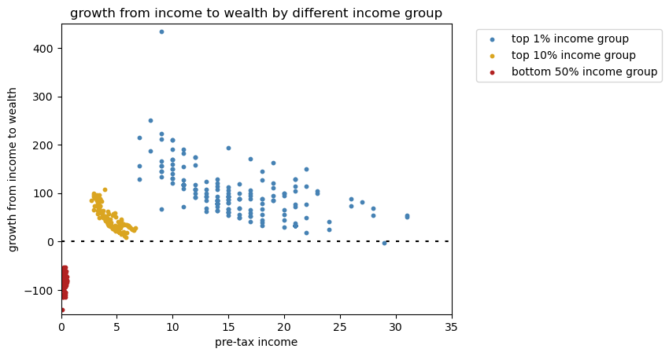

```python
main('Income_and_wealth_and_continent_number.csv')
```

```python
# Be sure to select ALL THE FILES YOU NEED (including csv's)
# when you submit. As usual, you cannot edit this cell.
# Instead, run this cell to start the submission process.
from cs103 import submit

COURSE = 101855
ASSIGNMENT = 1291659 # Final submission

submit(COURSE, ASSIGNMENT)

# If your submission fails, SUBMIT by downloading your files and uploading them
# to Canvas. You can learn how on the page "How to submit your Jupyter notebook"
# on our Canvas site.
```

# Please double check your submission on Canvas to ensure that the right files (Jupyter file + CSVs) have been submitted and that the files do not contain unexpected errors.

**You should always check your submission on Canvas. It is your responsibility to ensure that the correct file has been submitted for grading.** Regrade or accomodation requests using reasoning such as "I didn't realize I submitted the wrong file"/"I didn't realize the submission didn't work"/"I didn't realize I didn't save before submitting so some of my work is missing" will not be considered.